# Descriptive Analysis of E-book Sales of a Publishing Company

Nazish Khan

# Topic: E-book Sales Data Analysis

This section will examine data from an e-book a publishing company. The data provided contains information on e-book sales over a period of many months. Each row in the data represents one book. The values of the variables are taken across the entire time period, so daily.sales is the average number of sales (minus refunds) across all days in the period, and sale.price is the average price for which the book sold in the period.

In this analysis, we will answer the following: Do books have more/fewer sales depending upon their average review scores and total number of reviews. What is the effect of sale price upon the number of sales, and is this different across genres?

The data dictionary used for this analysis includes information about each variable, such as its variable name, description, and data type.

| Variable | Description | Data Type |
| --- | --- | --- |
| sold.by | Entity or company that sold the book | Character |
| publisher.type | Type of publisher (indie, big five, small/medium, etc.) | Character |
| genre | Genre of the book (e.g., adult fiction, YA fiction) | Character |
| avg.review | Average review rating of the book | Numeric |
| daily.sales | Daily sales of the book | Numeric |
| total.reviews | Total number of reviews for the book | Integer |
| sale.price | Price at which the book is sold | Numeric |

# Loading the required libraries

```r
knitr::opts_chunk$set()
library(dplyr)
library(ggplot2)
library(knitr) # for table()
library(Rmisc) # for CI()
library(emmeans) # for emmeans() and pairs()
library(gridExtra) # for grid.arrange()
library(Hmisc)
library(car)
library(tidyverse)
library(kableExtra)
options(width=100)
```

## Load the data into books dataframe

Review 10 records of the dataset books

```r
books<- read.csv("publisher_sales.csv")
head(books,10)
```

```
##                                 sold.by publisher.type         genre avg.review daily.sales
## 1        Amazon Digital Services,  Inc.          indie adult_fiction       4.50       84.39
## 2              HarperCollins Publishers       big five    YA_fiction       4.64      113.11
## 3        Amazon Digital Services,  Inc.   small/medium adult_fiction       2.50       70.81
## 4        Amazon Digital Services,  Inc.   small/medium    YA_fiction       4.50      149.37
## 5        Amazon Digital Services,  Inc.   small/medium    YA_fiction       4.98      135.65
## 6        Amazon Digital Services,  Inc.   small/medium adult_fiction       3.98       78.16
## 7                      Random House LLC       big five   non_fiction       4.62       75.60
## 8  Simon and Schuster Digital Sales Inc       big five   non_fiction       3.50       62.32
## 9        Amazon Digital Services,  Inc.   small/medium   non_fiction       4.64       94.64
## 10 Simon and Schuster Digital Sales Inc       big five   non_fiction       4.56       70.45
##    total.reviews sale.price
## 1            151       5.12
## 2            184       6.91
## 3            125       6.27
## 4            225       4.91
## 5            194       7.39
## 6            123       5.14
## 7            130      17.57
## 8            110      14.70
## 9            129      11.69
## 10           119      17.10
```

## Data Understanding

```r
#Structure of the dataset
str(books)
```

```
## 'data.frame':    6000 obs. of  7 variables:
##  $ sold.by       : chr  "Amazon Digital Services,  Inc." "HarperCollins Publishers" "Amazon Digital Services,  Inc." "Amazon Digital Services,  Inc." ...
##  $ publisher.type: chr  "indie" "big five" "small/medium" "small/medium" ...
##  $ genre         : chr  "adult_fiction" "YA_fiction" "adult_fiction" "YA_fiction" ...
##  $ avg.review    : num  4.5 4.64 2.5 4.5 4.98 3.98 4.62 3.5 4.64 4.56 ...
##  $ daily.sales   : num  84.4 113.1 70.8 149.4 135.7 ...
##  $ total.reviews : int  151 184 125 225 194 123 130 110 129 119 ...
##  $ sale.price    : num  5.12 6.91 6.27 4.91 7.39 ...
```

```r
#Summarise the dataset
summary(books)
```

```
##    sold.by          publisher.type        genre             avg.review     daily.sales
##  Length:6000        Length:6000        Length:6000        Min.   :0.000   Min.   : -0.53
##  Class :character   Class :character   Class :character   1st Qu.:4.090   1st Qu.: 64.22
##  Mode  :character   Mode  :character   Mode  :character   Median :4.410   Median : 81.59
##                                                           Mean   :4.269   Mean   : 86.37
##                                                           3rd Qu.:4.610   3rd Qu.:104.73
##                                                           Max.   :4.980   Max.   :209.34
##  total.reviews     sale.price
##  Min.   :  0.0   Min.   : 1.17
##  1st Qu.:104.0   1st Qu.: 7.34
##  Median :128.0   Median : 9.31
##  Mean   :132.7   Mean   :10.30
##  3rd Qu.:163.0   3rd Qu.:13.58
##  Max.   :243.0   Max.   :22.00
```

## Data Type Check

```r
#Convert the character features into factors
books$genre <- as.factor(books$genre)
books$publisher.type <- as.factor(books$publisher.type)
books$sold.by <- as.factor(books$sold.by)

#Check the proportions of columns genre, publisher.type, and sold.by
table(books$genre)
```

```
##
## adult_fiction   non_fiction    YA_fiction
##          2000          2000          2000
```

```r
table(books$publisher.type)
```

```
##
##        amazon      big five         indie single author  small/medium
##            92          1688          1243           789          2188
```

```r
table(books$sold.by)
```

```
##
##       Amazon Digital Services,  Inc.                     Cengage Learning
##                                 4271                                    2
##                            DC Comics                  Hachette Book Group
##                                   27                                  125
##   HarperCollins Christian Publishing             HarperCollins Publishers
##                                   17                                  274
##             HarperCollins Publishing                  Idea & Design Works
##                                   25                                   12
##                            Macmillan              Penguin Group (USA) LLC
##                                  172                                  346
##                     Random House LLC               Random House Mondadori
##                                  486                                    2
## Simon and Schuster Digital Sales Inc
##                                  241
```

## Data Integrity and Outlier Check

```r
# Check for missing values
any(is.na(books))
```

```
## [1] FALSE
```

```r
# Check for duplicates based on all columns
duplicated_rows <- duplicated(books)

# Print rows with duplicates
print(books[duplicated_rows, ])
```

```
## [1] sold.by        publisher.type genre          avg.review     daily.sales    total.reviews
## [7] sale.price
## <0 rows> (or 0-length row.names)
```

There is no missing value in out dataset. Also, there are no duplicate records available in the dataset.

## Outliers Identification and Handling

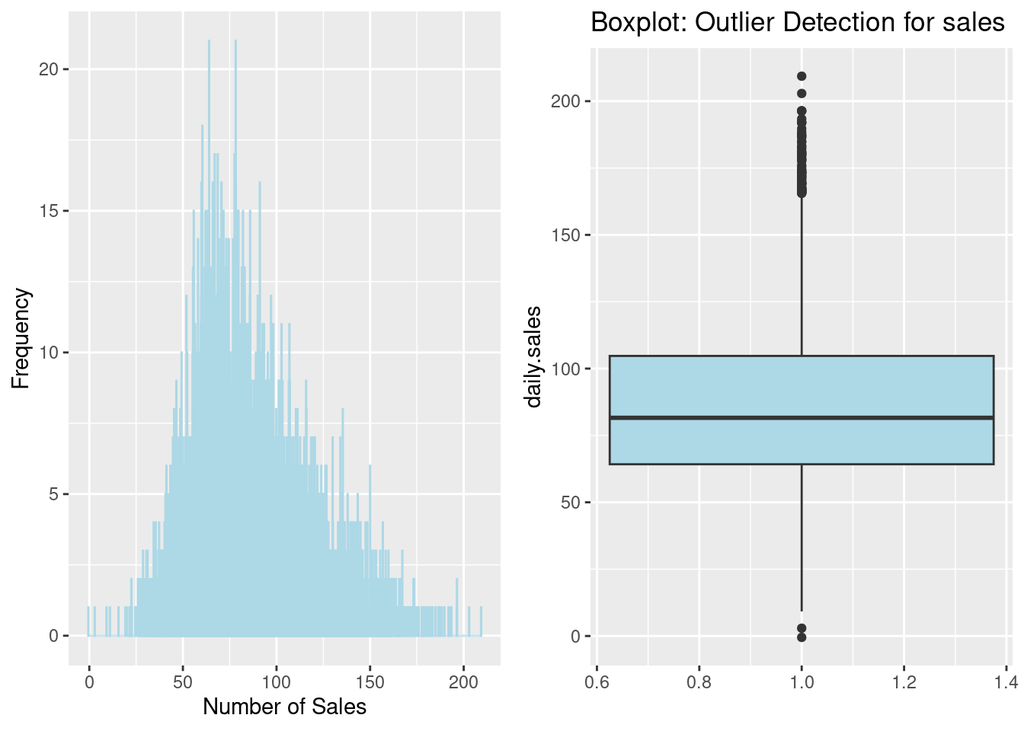

```r
grid.arrange(
#plot the distribution of hires data
ggplot(books) + geom_histogram(aes(x=daily.sales), binwidth = 0.1,color="lightblue") + xlab("Number of Sales") +ylab("Frequency"),

# Create a boxplot for daily.sales to check for any unusual points
ggplot(books, aes(x = 1, y = daily.sales)) +
  geom_boxplot(fill = "lightblue") +
  ggtitle("Boxplot: Outlier Detection for sales") +
  xlab("") +  # Remove x-axis label
  ylab("daily.sales"),  # Y-axis label
ncol=2
)
```

This boxplot is showing daily sales greater than 160 as outliers but those are not exactly outliers so won’t be handling them here. Additionally I did further analysis by removing the records having greater value than 160, however, it didn’t improve the analysis outcome so leaving them as it is.

On the other hand, we can’t have daily.sales as a negative value and here we can see there is a point which is less than zero.so let’s handle that.

```r
#Check out the records where daily.sales is negative
remove_outliers <- books[books$daily.sales <= 0,]
dim(remove_outliers)
```

```
## [1] 1 7
```

```r
#Filter the dataset when daily sales is greater than zero and less than 200
books <- books[books$daily.sales > 0 & books$daily.sales < 200,]
#check the dimension again
dim(books)
```

```
## [1] 5997    7
```

```r
#Let's create a new datafarme without daily.sales outliers for further analysis
no_outlier <- books[!(books$daily.sales > 160),]

#Remove the outliers in the daily.sales and check the dimension
dim(books)
```

```
## [1] 5997    7
```

```r
#check the size of the daily.sales greater than 160
dim(no_outlier)
```

```
## [1] 5889    7
```

```r
#Let's check if there is any exceptions in the average review if total reviews are zero
total_reviews_zero <- filter(books, total.reviews == 0 & avg.review == 1)
print(total_reviews_zero[c("avg.review", "total.reviews")])
```

```
## [1] avg.review    total.reviews
## <0 rows> (or 0-length row.names)
```

```r
sale_price_zero <- filter(books, sale.price == 0)
#print(sale_price_zero[c("sale.price", "daily.sales")])
```

So here, we have created 2 dataframe, one without outliers and second is with records less than 200 daily sales.

Assumptions to consider: When Total reviews are zero then average review should be zero not vice versa. There is no exceptions here.

## Data Distribution and Visualisation

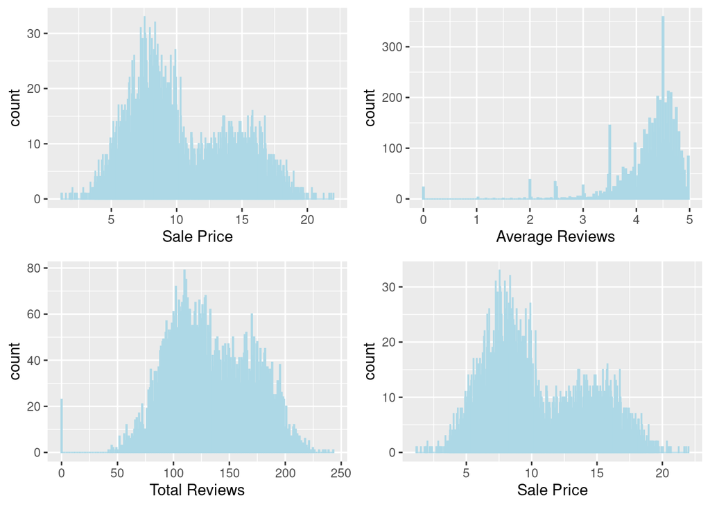

```r
#Check distribution of other columns
grid.arrange(
ggplot(books) + geom_histogram(aes(x=sale.price), binwidth = 0.025, color="lightblue") + xlab("Sale Price"),
ggplot(books) + geom_histogram(aes(x=avg.review), binwidth = 0.025,color="lightblue") + xlab("Average Reviews"),
ggplot(books) + geom_histogram(aes(x=total.reviews), binwidth = 0.7,color="lightblue") + xlab("Total Reviews"),
ggplot(books) + geom_histogram(aes(x=sale.price), binwidth = 0.025,color="lightblue") + xlab("Sale Price")
)
```

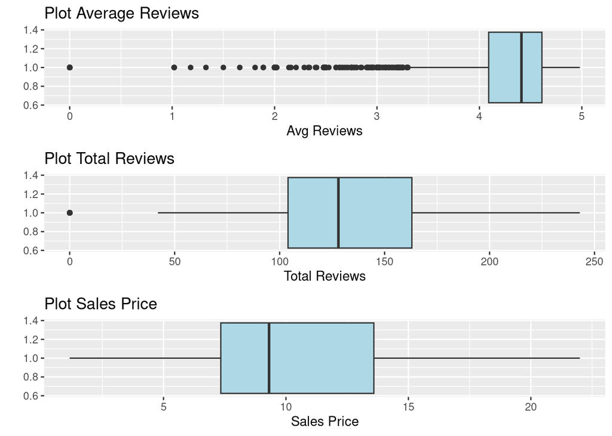

```r
#Check Outliers in terms of Average Reviews, Total Reviews, Sales.Price, and Genres
grid.arrange(
ggplot(books, mapping=aes(x=avg.review, y=1))+
  geom_boxplot(fill = "lightblue")+
  labs(title="Plot Average Reviews", x ="Avg Reviews", y=""),
ggplot(books, mapping=aes(x=total.reviews,y=1))+
  geom_boxplot(fill = "lightblue")+
  labs(title="Plot Total Reviews", x ="Total Reviews", y=""),
ggplot(books, mapping=aes(x=sale.price,y=1))+
  geom_boxplot(fill = "lightblue")+
  labs(title="Plot Sales Price", x ="Sales Price", y="")
)
```

Here in the average review, quite a few points are showing out of the interquartile ranges, which doesn’t mean that they will be treated as the outliers because average can be 0 to less than 4.

## Correlation Matrix between the features of the dataset

```r
#Create the Corelation matrix with all the numeric variables
cor_matrix <- rcorr(as.matrix(select(books, daily.sales, avg.review, total.reviews, sale.price)))
cor_matrix
```

```
##               daily.sales avg.review total.reviews sale.price
## daily.sales          1.00      -0.02          0.66      -0.51
## avg.review          -0.02       1.00          0.09       0.01
## total.reviews        0.66       0.09          1.00      -0.54
## sale.price          -0.51       0.01         -0.54       1.00
##
## n= 5997
##
##
## P
##               daily.sales avg.review total.reviews sale.price
## daily.sales               0.1128     0.0000        0.0000
## avg.review    0.1128                 0.0000        0.6870
## total.reviews 0.0000      0.0000                   0.0000
## sale.price    0.0000      0.6870     0.0000
```

daily.sales: Correlation: Strong positive correlation (0.66) with total.reviews, moderate negative correlation (-0.51) with sale.price. P-Value: P-value less than 0.05, indicating a statistically significant correlation with total.reviews and sale.price. However, with avg.review, the p-value(0.1128) is greater than 0.05, showing there is no statistical significant with the feature.

total.reviews: Correlation: Strong positive correlation (0.66) with daily.sales, strong negative correlation (-0.54) with sale.price. P-Value: P-value less than 0.05, indicating a statistically significant correlation with daily.sales and sale.price.

sale.price:Correlation: Moderate negative correlation (-0.51) with daily.sales, strong negative correlation (-0.54) with total.reviews. P-Value: P-value less than 0.05, indicating a statistically significant correlation with daily.sales and total.reviews.However, with avg.review, the p-value(0.6870) is greater than 0.05, showing there is no statistical significant with the feature.

Let’s test our NHST and Estimation on the given dataset

```r
#one sample t-test performed to assesses if sample mean significantly differs from hypothesized population mean for statistical inference.
t.test(books$daily.sales)
```

```
##
##  One Sample t-test
##
## data:  books$daily.sales
## t = 221.92, df = 5996, p-value < 2.2e-16
## alternative hypothesis: true mean is not equal to 0
## 95 percent confidence interval:
##  85.58393 87.10941
## sample estimates:
## mean of x
##  86.34667
```

```r
CI(books$daily.sales) # from library Rmisc
```

```
##    upper     mean    lower
## 87.10941 86.34667 85.58393
```

A one-sample t-test on daily book sales (t = 221.92, df = 5996, p < 2.2e-16) found a significant deviation from zero. The 95% confidence interval [85.58, 87.11] and mean 86.35 indicate a statistically different true mean, rejecting the null hypothesis.

## Part 1

### Average Reviews Impact on the Daily Sales

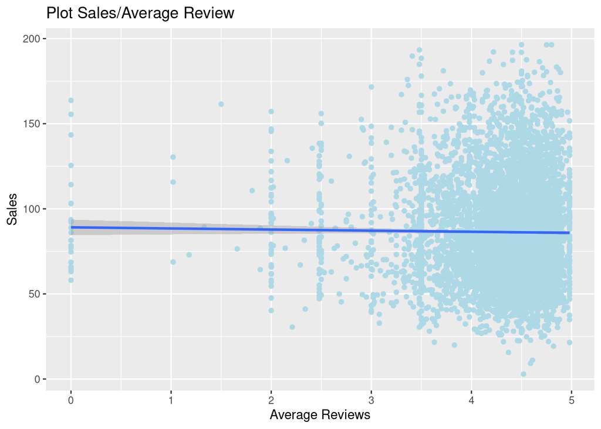

```r
#Plot a scatter plot for average review vs daily sales with regression line
ggplot(books, aes(x = avg.review, y = daily.sales)) +
  geom_point(color="lightblue")+
  geom_smooth()+
  guides(alpha = "none")+
  labs(title="Plot Sales/Average Review", x ="Average Reviews", y="Sales")
```

```r
# Regression analysis on 'Daily Sales' w.r.t. Average Review
m1 <- lm(daily.sales ~ avg.review, data = books)
summary(m1)
```

```
##
## Call:
## lm(formula = daily.sales ~ avg.review, data = books)
##
## Residuals:
##     Min      1Q  Median      3Q     Max
## -83.165 -22.107  -4.716  18.229 110.599
##
## Coefficients:
##             Estimate Std. Error t value Pr(>|t|)
## (Intercept)  90.9763     2.9453  30.889   <2e-16 ***
## avg.review   -1.0844     0.6839  -1.586    0.113
## ---
## Signif. codes:  0 '***' 0.001 '**' 0.01 '*' 0.05 '.' 0.1 ' ' 1
##
## Residual standard error: 30.13 on 5995 degrees of freedom
## Multiple R-squared:  0.0004193,  Adjusted R-squared:  0.0002525
## F-statistic: 2.515 on 1 and 5995 DF,  p-value: 0.1128
```

```r
( m1.emm <- emmeans(m1, ~ avg.review) )
```

```
##  avg.review emmean    SE   df lower.CL upper.CL
##        4.27   86.3 0.389 5995     85.6     87.1
##
## Confidence level used: 0.95
```

```r
#(  m1.contrast <- confint(pairs(m1.emm))  )
```

Explanation: The linear regression analysis between daily book sales and average reviews indicates a non-significant relationship (β(coefficient) = -1.08, p = 0.113). The model has low explanatory power (R² = 0.0004), suggesting that average reviews alone poorly predict daily sales. The estimated mean sales for books with an average review of 4.27 is 86.3, with a confidence interval of 85.6 to 87.1. The intercept, representing the expected daily sales when the average review is zero, is 90.98. Overall, the relationship between average reviews and daily sales is not statistically robust, and other factors may contribute to the variability in sales. The regression line is showing a decline in the trend.

Let’s check whether the model is not fitting or issue caused by the outliers.

```r
#Regression Analysis after removing some points out of the interquartile ranges in the daily.sales
m1.2 <- lm(daily.sales ~ avg.review, data = no_outlier)
summary(m1.2)
```

```
##
## Call:
## lm(formula = daily.sales ~ avg.review, data = no_outlier)
##
## Residuals:
##    Min     1Q Median     3Q    Max
## -81.69 -20.85  -3.96  18.30  75.52
##
## Coefficients:
##             Estimate Std. Error t value Pr(>|t|)
## (Intercept)  87.9738     2.7771  31.679   <2e-16 ***
## avg.review   -0.7469     0.6446  -1.159    0.247
## ---
## Signif. codes:  0 '***' 0.001 '**' 0.01 '*' 0.05 '.' 0.1 ' ' 1
##
## Residual standard error: 28.06 on 5887 degrees of freedom
## Multiple R-squared:  0.000228,   Adjusted R-squared:  5.818e-05
## F-statistic: 1.343 on 1 and 5887 DF,  p-value: 0.2466
```

```r
dim(no_outlier)
```

```
## [1] 5889    7
```

The model with the outliers removed has a non-significant relationship between daily sales and average reviews (β = -0.75, p = 0.247). Comparing it to the previous model, both show weak predictive power (R² < 0.001) and non-significant relationships. Therefore, neither model provides strong evidence that average reviews alone significantly predict daily book sales.

[figure not shown]

```r
#anova(m.sales.baseline, m1)

## The estimation approach to regression coefficients

#We can use `coef()` to get the coefficients and `confint()` to get confidence intervals for our coefficients

cbind(coefficient=coef(m1), confint(m1))
```

```
##             coefficient     2.5 %     97.5 %
## (Intercept)   90.976252 85.202433 96.7500719
## avg.review    -1.084437 -2.425052  0.2561775
```

Intercept (90.98): The estimated baseline daily sales when avg.review is zero. The 95% confidence interval for the intercept is [85.20, 96.75].

avg.review (-1.08): The estimated change in daily sales for a one-unit increase in avg.review. The 95% confidence interval for this coefficient is [-2.43, 0.26]. Since the confidence interval includes zero, the effect of avg.review is not statistically significant at a conventional significance level of 0.05.

### Regression Analysis on Daily Sales in respect of Total Reviews

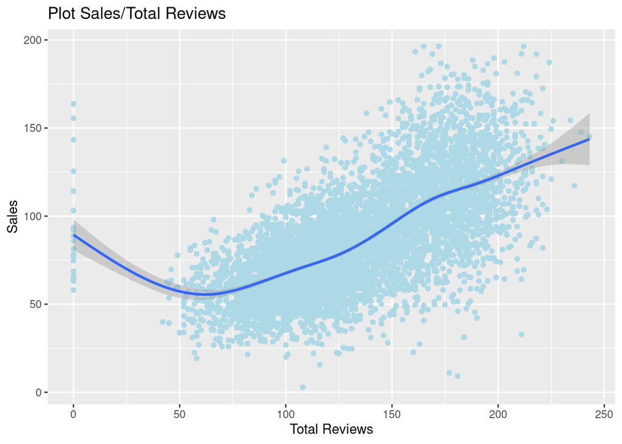

```r
#Scatter Plot of Daily Sales vs Total Reviews
ggplot(books, aes(x = total.reviews, y = daily.sales)) +
  geom_point(color="lightblue")+
  geom_smooth()+
  guides(alpha = "none")+
  labs(title="Plot Sales/Total Reviews", x ="Total Reviews", y="Sales")
```

```r
# Linear regression model for Daily Sales vs. Total Number of Reviews
m2 <- lm(daily.sales ~ total.reviews, data = books)
summary(m2)
```

```
##
## Call:
## lm(formula = daily.sales ~ total.reviews, data = books)
##
## Residuals:
##      Min       1Q   Median       3Q      Max
## -102.605  -14.704   -1.115   13.449  147.193
##
## Coefficients:
##                Estimate Std. Error t value Pr(>|t|)
## (Intercept)   16.506537   1.067282   15.47   <2e-16 ***
## total.reviews  0.526456   0.007738   68.04   <2e-16 ***
## ---
## Signif. codes:  0 '***' 0.001 '**' 0.01 '*' 0.05 '.' 0.1 ' ' 1
##
## Residual standard error: 22.64 on 5995 degrees of freedom
## Multiple R-squared:  0.4357, Adjusted R-squared:  0.4356
## F-statistic:  4629 on 1 and 5995 DF,  p-value: < 2.2e-16
```

```r
( m2.emm <- emmeans(m2, ~ total.reviews) )
```

```
##  total.reviews emmean    SE   df lower.CL upper.CL
##            133   86.3 0.292 5995     85.8     86.9
##
## Confidence level used: 0.95
```

```r
#(  m2.contrast <- confint(pairs(m2.emm))  )
```

```r
#Let's run anova function as well with the base line
m.sales.baseline <- lm(daily.sales~1, data = books)
summary(m.sales.baseline)
```

```
##
## Call:
## lm(formula = daily.sales ~ 1, data = books)
##
## Residuals:
##     Min      1Q  Median      3Q     Max
## -83.437 -22.127  -4.757  18.353 110.063
##
## Coefficients:
##             Estimate Std. Error t value Pr(>|t|)
## (Intercept)  86.3467     0.3891   221.9   <2e-16 ***
## ---
## Signif. codes:  0 '***' 0.001 '**' 0.01 '*' 0.05 '.' 0.1 ' ' 1
##
## Residual standard error: 30.13 on 5996 degrees of freedom
```

```r
anova(m.sales.baseline, m1)
```

```
## Analysis of Variance Table
##
## Model 1: daily.sales ~ 1
## Model 2: daily.sales ~ avg.review
##   Res.Df     RSS Df Sum of Sq      F Pr(>F)
## 1   5996 5443485
## 2   5995 5441203  1    2282.3 2.5146 0.1128
```

```r
anova(m.sales.baseline, m2)
```

```
## Analysis of Variance Table
##
## Model 1: daily.sales ~ 1
## Model 2: daily.sales ~ total.reviews
##   Res.Df     RSS Df Sum of Sq      F    Pr(>F)
## 1   5996 5443485
## 2   5995 3071618  1   2371867 4629.3 < 2.2e-16 ***
## ---
## Signif. codes:  0 '***' 0.001 '**' 0.01 '*' 0.05 '.' 0.1 ' ' 1
```

The analysis comprises two models:

Model 1 (Baseline): Predicting daily.sales solely with an intercept.

Residual Sum of Squares (RSS): 5443485 Degrees of Freedom (Res.Df): 5996 Model 2 (Enhanced): Predicting daily.sales with additional predictors (avg.review or total.reviews).

For avg.review: Residual Sum of Squares (RSS): 5441203 Degrees of Freedom (Res.Df): 5995 F-statistic: 2.51, p-value: 0.1128 (insufficient evidence of improvement) For total.reviews: Residual Sum of Squares (RSS): 3071618 Degrees of Freedom (Res.Df): 5995 F-statistic: 4629.3, p-value: < 2.2e-16 (indicating significant enhancement) The F-statistic and p-value aid in evaluating whether the inclusion of predictors significantly enhances the model compared to the baseline. The results suggest that total.reviews contributes significantly, whereas avg.review does not.

### Analysis on Daily Sales w.r.t Total Reviews and Average Review

```r
m3 <- lm(daily.sales ~ avg.review * total.reviews, data = books)
summary(m3)
```

```
##
## Call:
## lm(formula = daily.sales ~ avg.review * total.reviews, data = books)
##
## Residuals:
##      Min       1Q   Median       3Q      Max
## -104.242  -14.417   -0.871   13.615   92.241
##
## Coefficients:
##                            Estimate Std. Error t value Pr(>|t|)
## (Intercept)               76.006931   4.154210  18.296  < 2e-16 ***
## avg.review               -14.619314   0.987836 -14.799  < 2e-16 ***
## total.reviews              0.141133   0.033081   4.266 2.02e-05 ***
## avg.review:total.reviews   0.095069   0.007821  12.155  < 2e-16 ***
## ---
## Signif. codes:  0 '***' 0.001 '**' 0.01 '*' 0.05 '.' 0.1 ' ' 1
##
## Residual standard error: 22.23 on 5993 degrees of freedom
## Multiple R-squared:  0.4557, Adjusted R-squared:  0.4554
## F-statistic:  1673 on 3 and 5993 DF,  p-value: < 2.2e-16
```

```r
( m3.emm <- emmeans(m3, ~ avg.review * total.reviews) )
```

```
##  avg.review total.reviews emmean    SE   df lower.CL upper.CL
##        4.27           133   86.2 0.288 5993     85.6     86.7
##
## Confidence level used: 0.95
```

```r
#(  m3.contrast <- confint(pairs(m3.emm))  )

#confidence interval.
confint(m3)
```

```
##                                 2.5 %      97.5 %
## (Intercept)               67.86318381  84.1506789
## avg.review               -16.55582788 -12.6828005
## total.reviews              0.07628168   0.2059839
## avg.review:total.reviews   0.07973647   0.1104019
```

```r
# Check for multicollinearity using vif
#vif(m3)

anova(m3)
```

```
## Analysis of Variance Table
##
## Response: daily.sales
##                            Df  Sum Sq Mean Sq   F value Pr(>F)
## avg.review                  1    2282    2282    4.6166 0.0317 *
## total.reviews               1 2405385 2405385 4865.5281 <2e-16 ***
## avg.review:total.reviews    1   73041   73041  147.7450 <2e-16 ***
## Residuals                5993 2962776     494
## ---
## Signif. codes:  0 '***' 0.001 '**' 0.01 '*' 0.05 '.' 0.1 ' ' 1
```

In the multiple linear regression model assessing daily.sales with avg.review and total.reviews, the following key points emerge:

Main Effects:

avg.review: A negative association, suggesting that an increase in average reviews corresponds to a decrease in daily sales by approximately 14.62 units. total.reviews: Positively influences daily sales, indicating that each additional review contributes to an increase of about 0.14 units.

Interaction Effect:

The interaction term (avg.review:total.reviews) exhibits a significant positive impact, implying that the combined influence of both avg.review and total.reviews enhances their effect on daily.sales.

Model Fit:

The overall model is highly significant (F-statistic: 1673, p < 2.2e-16), indicating that the combination of predictors significantly improves the ability to predict daily.sales. These findings underscore the nuanced interplay between avg.review and total.reviews in influencing daily.sales.

### Summary

To answer the question “Do books have more/fewer sales depending upon their average review scores and total number of reviews?”

From the regression analysis on both the parameters, we can conclude that Average Review only doesn’t have a significant impact on the daily sales. However, Total Reviews do increase the daily sales with the increment in the reviews on the book(Coefficient: 0.52 and p-value: 2.2e-16).

Multiple Regression has showing that both of the attributes together have a significant impact on the daily sales.

## Part 2

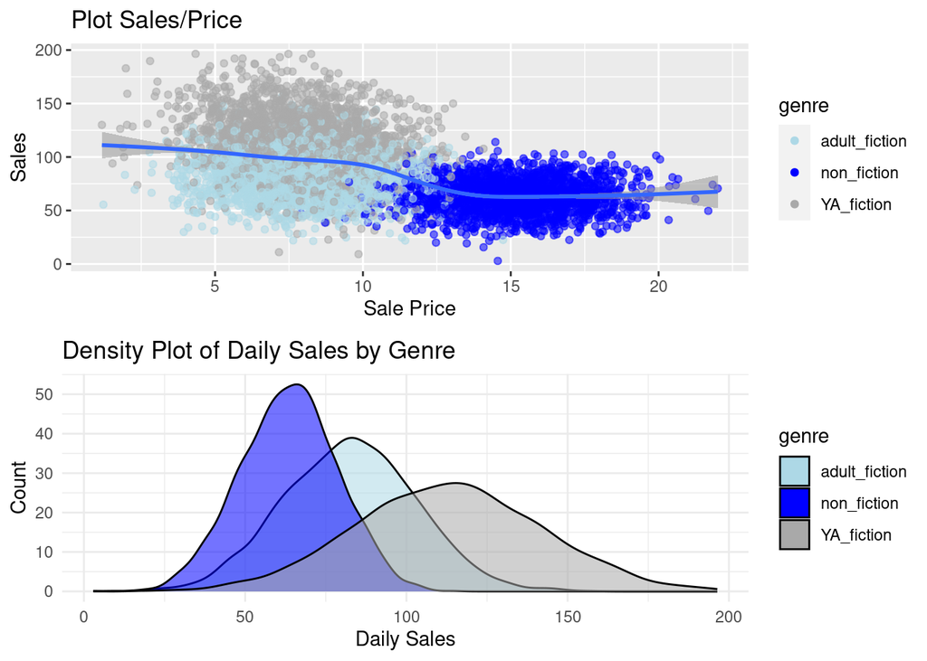

```r
grid.arrange(
#Scatter Plot of Daily Sales vs Average Reviews and Daily Sales vs Total Reviews
ggplot(books, aes(x = sale.price, y = daily.sales,  alpha=0.86)) +
  geom_point(aes(color = genre))+
  geom_smooth()+
  guides(alpha = "none")+
  scale_color_manual(values = c("lightblue", "blue", "darkgrey")) +
  labs(title="Plot Sales/Price", x ="Sale Price", y="Sales"),

#Plot a density plot to check the distributon od the daily sales by genres: adult fictioon, non-fiction, and YA fiction
ggplot(books, aes(x = daily.sales, fill = genre, alpha=0.5)) +
  geom_density(aes(y= ..count..)) +
   guides(alpha = "none")+
  labs(title = "Density Plot of Daily Sales by Genre", x = "Daily Sales", y = "Count") +
  scale_fill_manual(values = c("lightblue", "blue", "darkgrey")) +  # Set custom fill colors
  theme_minimal()
)
```

### Simple Regression on sale price and sales

```r
m_sale_price <- lm(daily.sales ~ sale.price, data = books)
summary(m_sale_price)
```

```
##
## Call:
## lm(formula = daily.sales ~ sale.price, data = books)
##
## Residuals:
##     Min      1Q  Median      3Q     Max
## -87.773 -17.380  -1.923  15.226 101.886
##
## Coefficients:
##              Estimate Std. Error t value Pr(>|t|)
## (Intercept) 127.24836    0.95397  133.39   <2e-16 ***
## sale.price   -3.97143    0.08673  -45.79   <2e-16 ***
## ---
## Signif. codes:  0 '***' 0.001 '**' 0.01 '*' 0.05 '.' 0.1 ' ' 1
##
## Residual standard error: 25.94 on 5995 degrees of freedom
## Multiple R-squared:  0.2591, Adjusted R-squared:  0.259
## F-statistic:  2097 on 1 and 5995 DF,  p-value: < 2.2e-16
```

```r
(  confint(m_sale_price)  )
```

```
##                  2.5 %    97.5 %
## (Intercept) 125.378238 129.11849
## sale.price   -4.141459  -3.80141
```

Linear Regression Model (lm):

Examines the relationship between daily sales and sale price. Significant negative association (Coefficient = -3.97143, p < 2e-16). For every unit increase in sale price, daily sales decrease by approximately 3.97 units. Intercept (127.24836) represents estimated daily sales when the sale price is zero. Good model fit (R-squared = 0.2591). Highly significant F-statistic (p < 2.2e-16), indicating overall model significance.

Confidence Intervals (confint):

95% confidence intervals for coefficients: Intercept: (125.378238, 129.11849) Sale price: (-4.141459, -3.80141) The intervals do not include zero, supporting the significance of intercept and sale price coefficients in predicting daily sales.

### Simple Regression on sale price and genre

Now to check impact of genres over daily sales:

```r
m_genre <- lm(daily.sales ~ genre, data = books)
summary(m_genre)
```

```
##
## Call:
## lm(formula = daily.sales ~ genre, data = books)
##
## Residuals:
##     Min      1Q  Median      3Q     Max
## -103.84  -13.95    0.22   13.56   83.38
##
## Coefficients:
##                  Estimate Std. Error t value Pr(>|t|)
## (Intercept)       82.5498     0.4960  166.43   <2e-16 ***
## genrenon_fiction -19.0468     0.7015  -27.15   <2e-16 ***
## genreYA_fiction   30.4773     0.7017   43.43   <2e-16 ***
## ---
## Signif. codes:  0 '***' 0.001 '**' 0.01 '*' 0.05 '.' 0.1 ' ' 1
##
## Residual standard error: 22.18 on 5994 degrees of freedom
## Multiple R-squared:  0.4582, Adjusted R-squared:  0.458
## F-statistic:  2534 on 2 and 5994 DF,  p-value: < 2.2e-16
```

```r
(  confint(m_genre)  )
```

```
##                      2.5 %    97.5 %
## (Intercept)       81.57747  83.52222
## genrenon_fiction -20.42193 -17.67166
## genreYA_fiction   29.10164  31.85295
```

```r
aov(daily.sales ~ genre, data = books)
```

```
## Call:
##    aov(formula = daily.sales ~ genre, data = books)
##
## Terms:
##                   genre Residuals
## Sum of Squares  2494053   2949432
## Deg. of Freedom       2      5994
##
## Residual standard error: 22.18252
## Estimated effects may be unbalanced
```

```r
anova(m_genre)
```

```
## Analysis of Variance Table
##
## Response: daily.sales
##             Df  Sum Sq Mean Sq F value    Pr(>F)
## genre        2 2494053 1247027  2534.3 < 2.2e-16 ***
## Residuals 5994 2949432     492
## ---
## Signif. codes:  0 '***' 0.001 '**' 0.01 '*' 0.05 '.' 0.1 ' ' 1
```

This linear model (LM) examines the influence of book genre on daily sales, with three levels: adult Fiction, Non-Fiction, and YA Fiction. Results reveal significant effects, for the reference “Adult Fiction” genre, the model predicts an average daily sales of approximately 82.55 units, also indicating that Non-Fiction decreases daily sales by 19.05 units (p < 2e-16), while YA Fiction increases daily sales by 30.48 units (p < 2e-16). The LM exhibits a good fit (R-squared: 0.458), and the analysis of variance (ANOVA) underscores the significance of genre in explaining the variability in daily sales (F-value: 2534.3, p < 2.2e-16). In conclusion, book genre significantly impacts daily sales, providing actionable insights for marketing and sales strategies.

### Check multicolinearity in our predictors sale price and genre

```r
m4 <- lm(daily.sales ~ sale.price * genre, data = books)
summary(m4)
```

```
##
## Call:
## lm(formula = daily.sales ~ sale.price * genre, data = books)
##
## Residuals:
##      Min       1Q   Median       3Q      Max
## -104.764  -13.659    0.206   13.549   84.407
##
## Coefficients:
##                             Estimate Std. Error t value Pr(>|t|)
## (Intercept)                  88.2127     2.0356  43.334  < 2e-16 ***
## sale.price                   -0.7104     0.2479  -2.865  0.00418 **
## genrenon_fiction            -23.6300     4.1701  -5.667 1.52e-08 ***
## genreYA_fiction              52.8219     2.8588  18.477  < 2e-16 ***
## sale.price:genrenon_fiction   0.6383     0.3457   1.847  0.06486 .
## sale.price:genreYA_fiction   -2.8134     0.3485  -8.072 8.30e-16 ***
## ---
## Signif. codes:  0 '***' 0.001 '**' 0.01 '*' 0.05 '.' 0.1 ' ' 1
##
## Residual standard error: 21.8 on 5991 degrees of freedom
## Multiple R-squared:  0.477,  Adjusted R-squared:  0.4765
## F-statistic:  1093 on 5 and 5991 DF,  p-value: < 2.2e-16
```

```r
#confidence interval.
confint(m4)
```

```
##                                    2.5 %      97.5 %
## (Intercept)                  84.22213244  92.2033196
## sale.price                   -1.19648160  -0.2243572
## genrenon_fiction            -31.80483194 -15.4552044
## genreYA_fiction              47.21767279  58.4261063
## sale.price:genrenon_fiction  -0.03932572   1.3159614
## sale.price:genreYA_fiction   -3.49665462  -2.1301079
```

```r
# Check for multicollinearity using vif
#vif(m4)
aov(m4)
```

```
## Call:
##    aov(formula = m4)
##
## Terms:
##                 sale.price     genre sale.price:genre Residuals
## Sum of Squares   1410517.3 1131993.4          53827.5 2847146.7
## Deg. of Freedom          1         2                2      5991
##
## Residual standard error: 21.79994
## Estimated effects may be unbalanced
```

The regression model for daily sales includes significant effects:

Intercept: 88.21 Sale Price: Negative impact (-0.71, p=0.004) Genre Effects: Non-fiction: Decreases sales significantly (-23.63, p<0.001) YA Fiction: Increases sales significantly (52.82, p<0.001) Interaction Effects: Sale Price & Non-fiction: Marginally significant (0.64, p=0.065) Sale Price & YA Fiction: Significant negative impact (-2.81, p<0.001) Model Fit: R-squared=0.477, F-statistic=1093 (p<0.001) The findings emphasize the nuanced influence of sale price, genre, and their interactions on daily sales.

### Model comparison using ANOVA

```r
m5 <- lm(daily.sales ~ sale.price + genre, data = books)
summary(m5)
```

```
##
## Call:
## lm(formula = daily.sales ~ sale.price + genre, data = books)
##
## Residuals:
##      Min       1Q   Median       3Q      Max
## -103.111  -13.742    0.291   13.533   83.773
##
## Coefficients:
##                  Estimate Std. Error t value Pr(>|t|)
## (Intercept)       93.9139     1.2378  75.874  < 2e-16 ***
## sale.price        -1.4256     0.1425 -10.005  < 2e-16 ***
## genrenon_fiction  -9.0631     1.2164  -7.451 1.06e-13 ***
## genreYA_fiction   30.4444     0.6960  43.741  < 2e-16 ***
## ---
## Signif. codes:  0 '***' 0.001 '**' 0.01 '*' 0.05 '.' 0.1 ' ' 1
##
## Residual standard error: 22 on 5993 degrees of freedom
## Multiple R-squared:  0.4671, Adjusted R-squared:  0.4668
## F-statistic:  1751 on 3 and 5993 DF,  p-value: < 2.2e-16
```

```r
#confidence interval.
confint(m5)
```

```
##                       2.5 %    97.5 %
## (Intercept)       91.487388 96.340324
## sale.price        -1.704965 -1.146309
## genrenon_fiction -11.447804 -6.678467
## genreYA_fiction   29.079937 31.808811
```

```r
# Check for multicollinearity using vif
vif(m5)
```

```
##                GVIF Df GVIF^(1/(2*Df))
## sale.price 3.750946  1        1.936736
## genre      3.750946  2        1.391667
```

```r
aov(m5)
```

```
## Call:
##    aov(formula = m5)
##
## Terms:
##                 sale.price   genre Residuals
## Sum of Squares     1410517 1131993   2900974
## Deg. of Freedom          1       2      5993
##
## Residual standard error: 22.00137
## Estimated effects may be unbalanced
```

```r
#compare model with interaction and without interaction
anova(m4,m5)
```

```
## Analysis of Variance Table
##
## Model 1: daily.sales ~ sale.price * genre
## Model 2: daily.sales ~ sale.price + genre
##   Res.Df     RSS Df Sum of Sq      F    Pr(>F)
## 1   5991 2847147
## 2   5993 2900974 -2    -53827 56.632 < 2.2e-16 ***
## ---
## Signif. codes:  0 '***' 0.001 '**' 0.01 '*' 0.05 '.' 0.1 ' ' 1
```

LM Model Explaination: Intercept: 93.91 Sale Price: Negative impact (-1.43, p<0.001) Genre Effects: Non-fiction: Decreases sales significantly (-9.06, p<0.001) YA Fiction: Increases sales significantly (30.44, p<0.001) Model Fit: R-squared=0.4671, F-statistic=1751 (p<0.001) This model suggests that sale price and genre both play crucial roles in influencing daily sales, providing valuable insights for strategic decision-making.

The 95% confidence intervals for the coefficients in the regression model are as follows:

Intercept: Between 91.49 and 96.34 Sale Price: Between -1.70 and -1.15 Genre Non-fiction: Between -11.45 and -6.68 Genre YA Fiction: Between 29.08 and 31.81

VIF Analysis: The GVIF values for sale.price and genre are both 3.75, and their respective GVIF^(1/(2Df)) values are approximately 1.94 and 1.39. These values indicate that there is a moderate level of multicollinearity in the model.

AOV Results: The ANOVA for model m5 reveals significant contributions from sale price and genre. Residuals, indicating unexplained variance, amount to 2,900,974 with 5,993 degrees of freedom. The estimated residual standard error is approximately 22.00137, and caution is advised due to the possibility of unbalanced predictor variable distributions.

ANOVA Results: ANOVA compares two models for daily sales in the books dataset. Model 1: Predicts daily sales with the interaction of sale price and genre. Model 2: Predicts daily sales with additive effects of sale price and genre. Results show a significant difference (F = 56.632, p < 2.2e-16) between the models. Including the interaction term improves model fit, emphasizing its role in explaining daily sales variability.

### Summary

Sale Price Impact: The negative coefficient for sale price across various models suggests that an increase in sale price is associated with a decrease in daily sales. This aligns with economic intuition, where higher prices often lead to reduced demand.

Genre Influence: The genre variable, with non-fiction and YA fiction as categories, significantly affects daily sales. Non-fiction negatively impacts sales, while YA fiction has a positive impact. This could indicate varying audience preferences and market dynamics.

Interaction Insight: The interaction term between sale price and genre uncovers nuanced effects. It signifies that the relationship between sale price and daily sales differs based on the genre, adding a layer of sophistication to the analysis.

Model Comparison: The F-statistic from ANOVA highlights that the interaction model outperforms the additive model, emphasizing the importance of considering the joint effect of sale price and genre.

Predictive Power: Despite the complexity introduced by interaction terms, these models demonstrate a relatively high predictive power, capturing a substantial portion of the variability in daily sales.

This comprehensive analysis provides actionable insights for stakeholders in the book industry, allowing for informed decision-making and strategic planning. Understanding how sale price and genre interact can guide pricing strategies and marketing efforts to optimize daily sales in the dynamic book market.

```
                                             *END*
```